# Modélisation de la probabilité de résignation

## Bagging

### Résultats de l’optimisation

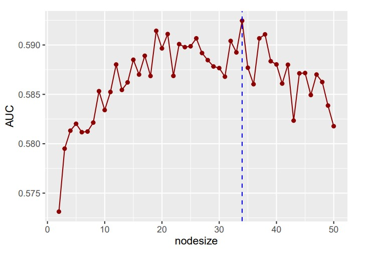

## Forêt aléatoire

- Taille de l’échantillon boostrap de 50%
- Nombre d’arbre nécessaire

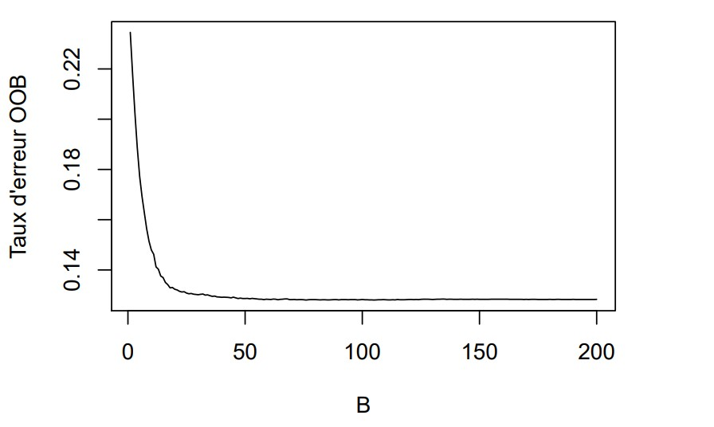

- Deux hyperparamètre à optimiser
  - taille minimal d’un noeud (nodesize)
  - nombre de prédicteurs choisi aléatoirement (mtry)

## Boosting de gradient stochastique

- Amélioration à l’itération t \[ \sum_{i=1}^n \mathcal{L} \left\{ y_i, \widehat{f}_{t-1}(x_i) + \widehat{f}_{\text{arbre}}^t(x_i) \right\} \]
- Avec fonction de perte \[ \mathcal{L} = - \sum_{k=1}^K \widehat{P}_{ik} \ln( \widehat{P}_{ik}) \]
- Taux d’apprentissage \(\lambda = 0.005\) , sous-échantillonnage de 75%
- Deux hyperparamètre à optimiser
  - nombre d’arbre (n.trees)
  - profondeur maximal des arbres (d)

## Boosting de gradient stochastique

### Résultats de l’optimisation

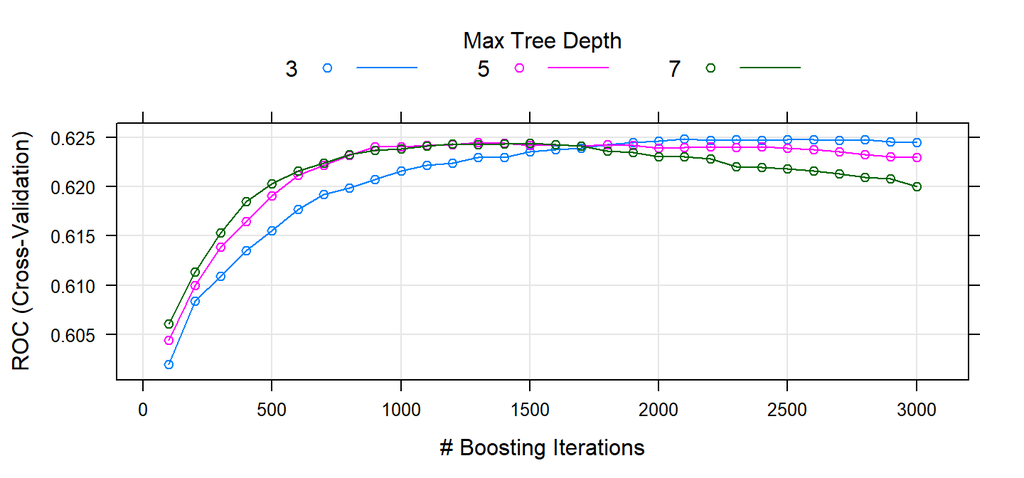

```
##    n.trees interaction.depth
## 21    2100                 3
```

## Comparaison de la performance des modèles

- Échantillon test 20%
- Comparaison avec la courbe ROC et l’AUC

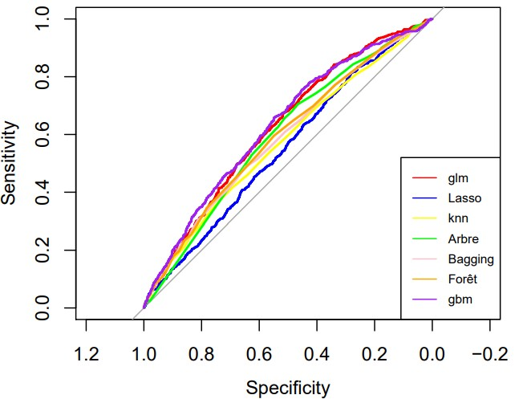

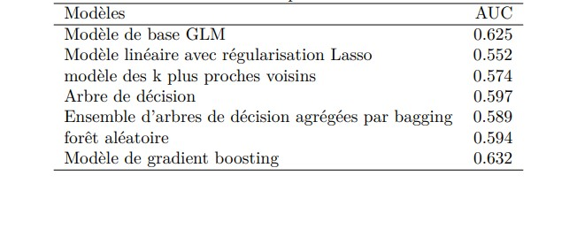

Côté, Marie-Pier. 2020. *ACT-3114 - Introduction à L’apprentissage Supervisé*. Recueil inédit; Université Laval.

Dutang, Christophe, and Arthur Charpentier. 2019. *CASdatasets: Insurance Datasets*. R Package Version 1.0-10. http://cas.uqam.ca/.

[figure not shown]

Hastie, Trevor, and Junyang Qian. 2016. *An Introduction to Glmnet*. https://cran.r-project.org/web/packages/glmnet/vignettes/glmnet.pdf.

Kuhn, Max. 2020. *Caret: Classification and Regression Training*. R Package Version 6.0-86. https://CRAN.R-project.org/package=caret.

[figure not shown]